# D17129705PSICAPart2

# Prediction of Sleep Hour on Week days

## Introduction:

Predicting the hours of sleep a person is taking on weekdays is depends on multiple factors like their mental health, quality of sleep, their sleep hours on weekends or the number of hour daily a person should sleep so they will not feel sleepy. However, there are other factors as well which might affect their sleeping hours. First of all to predict sleeping hours it has been shown by the researchers that Sleep depends on sleep quality and sleep quantity (Williams, J. and Cook, D. 2018). They explained sleep quantity as the amount of sleep needed by individual to make them feel at rest for the day. Previously, researches has been done to predict sleep pattern with the help of quality of sleep people getting in different environment (Merilahti, J., Saarinen, A., Parkka, J., Antila, K., Mattila, E. and Korhonen, I.,2007). Researches trying to get the sleep pattern by analyzing the study conducted between two groups of people. The study conducted for three months, inside and outside of their home. By the analysis of quality of sleep researchers they are trying to predict the sleep pattern. This has been done to test the accuracy of sleep pattern estimation by a device. Moreover, recent researches has been done which shows that anxiety affect the sleep of individuals (Goldstein-Piekarski, A., Greer, S., Saletin, J., Harvey, A., Williams, L. and Walker, M. 2018) although this research was specific to gender but it shows that anxiety play role in sleeping order of individuals. This study based on data collected by “Questionnaire for sleep” with (N= 271). Based on above mentioned researches the prediction of sleeping pattern in week night depends on following factors:-

```
1.  Quality of sleep which is categorical variable where range varies from 1 to 4 and defined as 1=very poor, poor ; 2=fair; 3=good;4=very good, excellent.
2.  Average hours of sleep needed not feel sleepy which is continuous data and values provided by individuals (n= 271).
3.  Anxiety score with range from 0-21. This can be considered as continuous as no category defined for each value of range.
4.  Hours of sleep on average each weekend.
```

The Prediction of average hour of sleep in weekdays is done by using Multiple Linear Regression by creating multiple Models based on below hypothesis

### Model 1:

H0: There is no significant prediction of hours of sleep in weekday by hours needed to sleep for not to feel sleepy and anxiety score. HA: There is no significant prediction of hours of sleep in weekday by hours needed to sleep for not to feel sleepy and anxiety score.

### Model 2:

H0: There is no significant prediction of hours of sleep in weekday by hours needed to sleep for not to feel sleepy, anxiety score and Quality of Sleep. HA: There is no significant prediction of hours of sleep in weekday by hours needed to sleep for not to feel sleepy, anxiety score and Quality of Sleep.

### Model 3:

H0: There is no significant prediction of hours of sleep in weekday by hours needed to sleep for not to feel sleepy, anxiety score, Quality of Sleep and average hour of sleep on weekends. HA: There is no significant prediction of hours of sleep in weekday by hours needed to sleep for not to feel sleepy, anxiety score , Quality of Sleep and average hour of sleep on weekends.

```r
library(readr) #For reading the data set
library(ggplot2)# For creating the plot
library(pander) # For creating table
library(foreign) #To work with SPSS data
library(lmSupport)#Extra functions for linear mode
library(stargazer)#pretty print regression output
library(dplyr)
library(car)
library(userfriendlyscience)
library(psych)#skew and kurtosis

sleep <- read.csv("sleep5ED.csv")
#Variable of interest
panderOptions('table.split.table', Inf)
Variable <-"
Concept                       | Variable Name | Statistical Type | Possible Values
Hours sleep in week nights    | hourwnit      | Scale            | Range from 3 to 10
Quality of sleep recoded
into 4 groups                 | qualsleeprec  | Nominal          | 1=poor,2=fair,3=good,4=excellent
anxiety score                 | anxiety       | Scale            | Range from 0 to 21
Hours sleep in week ends      | hourwend      | Scale            | Range from 3 to 14
How many hours sleep needed   | hourneed      | Scale            | Range from 2 to 16"
#Creating the table
DF <- read.delim(textConnection(Variable),header=FALSE,sep="|",strip.white=TRUE,stringsAsFactors=FALSE)
names(DF) <- unname(as.list(DF[1,]))
DF <- DF[-1,]
row.names(DF)<-NULL
pander(DF, style = 'rmarkdown')
```

| Concept | Variable Name | Statistical Type | Possible Values |
| --- | --- | --- | --- |
| Hours sleep in week nights | hourwnit | Scale | Range from 3 to 10 |
| Quality of sleep recoded |  |  |  |
| into 4 groups | qualsleeprec | Nominal | 1=poor,2=fair,3=good,4=excellent |
| anxiety score | anxiety | Scale | Range from 0 to 21 |
| Hours sleep in week ends | hourwend | Scale | Range from 3 to 14 |
| How many hours sleep needed | hourneed | Scale | Range from 2 to 16 |

```r
# Removing NA values from Variable on interest
Var_used <- c("hourwnit","qualsleeprec", "anxiety", "hourneed", "hourwend")
sleep_data <- na.omit(sleep[Var_used])
```

## Methodology

The “Questionnaire for sleep” contains 55 details which have been filled by 271 people. However for prediction of sleep pattern all the details provided is not useful. There are 5 variable of interests used to build the regression model. The variable used for the study contains some missing values which cannot be used for the study.

The data set contains 271 records with few missing values after removing the missing the relevant number of record is 258. This study deals with only 258 relevant records. The variables of interests used for the study are as following:

1. “hourwnit” : Prediction of Hours of sleep in weekdays(DEPENDENT VARIABLE)
2. “anxiety” : Anxiety Score (INDEPENDENT VARIABLE)
3. “qualsleeprec”: Quality of sleep (INDEPENDENT VARIABLE)
4. “hourneed” : Hours needed to sleep for not to feel sleepy(INDEPENDENT VARIABLE)
5. “hourwend”: Hours of sleep on Weekends(INDEPENDENT VARIABLE)

The Prediction of Dependent Variable is done on the basis of 4 Independent variables mentioned above. There are Three models created with the help of independent variables for the prediction of sleep hours. The Descriptive Statistics of the variables is explained in the next section.

## Data Set and Descriptive Analysis

### 1. “hourwnit”(DEPENDENT VARIABLE)

### 1.1. Variable explanation

“hourwnit” (n = 258, M = 6.97, SD = 1.07)is a continuous variable which explains average hour of sleep in weekdays. The maximum value selected is 10 hour of sleep and minimum value selected is 3. Maximum number of people i.e. 88 people selected as 7 hour of on an average in each week nights.

```r
#Descriptive statisics
pastecs::stat.desc(sleep_data$hourwnit, basic=F)
```

```
##       median         mean      SE.mean CI.mean.0.95          var
##   7.00000000   6.97093023   0.06681791   0.13158034   1.15187540
##      std.dev     coef.var
##   1.07325458   0.15396146
```

### 1.2. Descriptive Analysis

```r
#skewness and kurtosis
tpskew<-skew(sleep_data$hourwnit)
tpkurt<- kurtosi(sleep_data$hourwnit)
stdskew<-tpskew[1]/tpskew[2]
stdkurt<-tpkurt[1]/tpkurt[2]
tpskew
```

```
## [1] -0.4328271
```

```r
tpkurt
```

```
## [1] 0.6311442
```

```r
outliers <- sleep_data %>%
  filter(scale(hourwnit) >3.29 | scale(hourwnit) < -3.29)
#count them using dplyr summarize
numoutliers<-outliers %>%
  summarize(count=n())
fullcount<-sleep_data %>%
  summarize(count=n())
numoutliers
```

```
##   count
## 1     1
```

```r
fullcount
```

```
##   count
## 1   258
```

### 1.3 Normality Plot:

Below graph shows the Normality distribution and density curve of hours of sleep in week night.

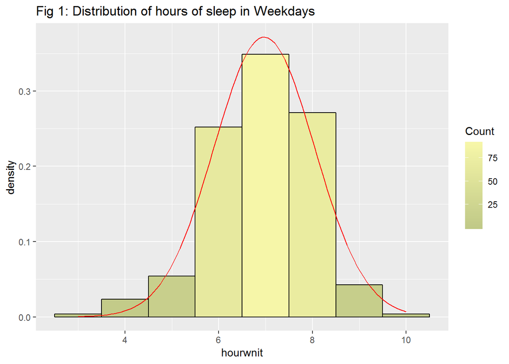

```r
#Create the histogram
hourwnit_plot <- ggplot(sleep_data, aes(x= hourwnit)) +
  labs(x="hourwnit") +
  geom_histogram(binwidth=1, color = "black", aes(y=..density..,fill=..count..)) +
  scale_fill_gradient("Count", low="#C0C987", high="#F6F6A8")
#adding a normal curve, stat_function to compute a normalised score,the mean and standard deviation
hourwnit_plot <- hourwnit_plot + stat_function(fun=dnorm, color="red",args=list(mean=mean(sleep_data$hourwnit, na.rm=TRUE), sd=sd(sleep_data$hourwnit)))
hourwnit_plot<-hourwnit_plot +ggtitle('Fig 1: Distribution of hours of sleep in Weekdays')
#to display the graph request the contents of the variable be shown
hourwnit_plot
```

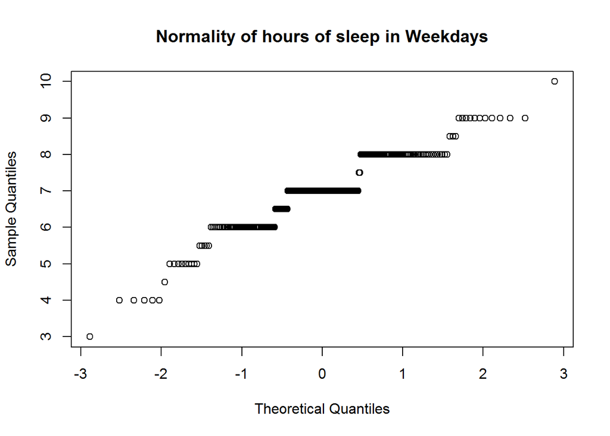

```r
#Create qqplot for nomality distribution
qqnorm(sleep_data$hourwnit, main = "Normality of hours of sleep in Weekdays")
```

### 2 “anxiety”(INDEPEDENT VARIABLE)

### 2.1: Variable explanation:

“anxiety”(n= 258, M = 6.25, SD = 3.45) is considered as continuous variable which has range from 0-17.

```r
#Descriptive statisics
pastecs::stat.desc(sleep_data$anxiety, basic=F)
```

```
##       median         mean      SE.mean CI.mean.0.95          var
##    6.0000000    6.2558140    0.2151445    0.4236706   11.9420867
##      std.dev     coef.var
##    3.4557324    0.5524033
```

### 2.2: Descriptive Analysis:

```r
#skewness and kurtosis from semTools with standard error
tpskew<-skew(sleep_data$anxiety)
tpkurt<-kurtosi(sleep_data$anxiety)
stdskew<-tpskew[1]/tpskew[2]
stdkurt<-tpkurt[1]/tpkurt[2]
tpskew
```

```
## [1] 0.590413
```

```r
tpkurt
```

```
## [1] 0.0665462
```

```r
outliers <- sleep_data %>%
  filter(scale(anxiety) >3.29 | scale(anxiety) < -3.29)
#count them using dplyr summarize
numoutliers<-outliers %>%
  summarize(count=n())
fullcount<-sleep_data %>%
  summarize(count=n())
numoutliers
```

```
##   count
## 1     0
```

```r
fullcount
```

```
##   count
## 1   258
```

### 1.3 Normality Plot:

Below graph shows the Normality distribution and density curve of anxiety score.

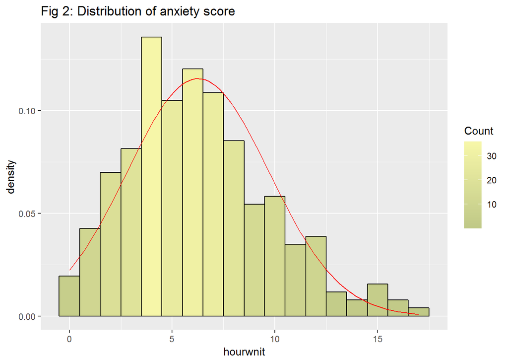

```r
#Create the histogram
anxiety_plot <- ggplot(sleep_data, aes(x= anxiety)) +
  labs(x="hourwnit") +
  geom_histogram(binwidth=1, color = "black", aes(y=..density..,fill=..count..)) +
  scale_fill_gradient("Count", low="#C0C987", high="#F6F6A8")
#adding a normal curve, stat_function to compute a normalised score,the mean and standard deviation
anxiety_plot <- anxiety_plot + stat_function(fun=dnorm, color="red",args=list(mean=mean(sleep_data$anxiety, na.rm=TRUE), sd=sd(sleep_data$anxiety)))
anxiety_plot<-anxiety_plot +ggtitle('Fig 2: Distribution of anxiety score')
anxiety_plot
```

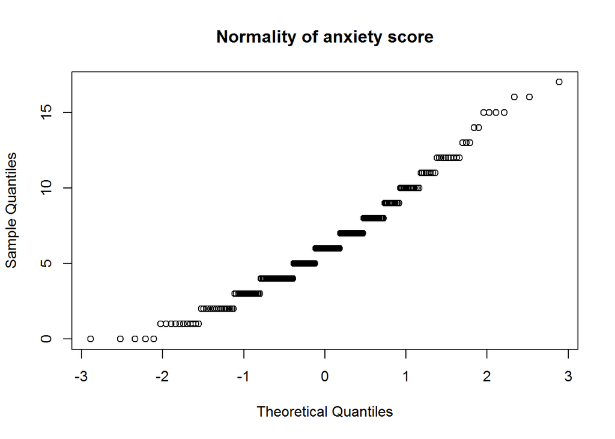

```r
#Create a qqplot
qqnorm(sleep_data$anxiety, main = "Normality of anxiety score")
```

### 3 “qualsleeprec”(INDEPEDENT VARIABLE)

### 3.1: Variable explanation:

“qualsleeprec”(n=258) is the categorical variable range between 1-4 where each number shows below category of quality of sleep : a. 1 = very poor, poor b. 2 = fair c. 3 = good d. 4 = very good, excellent

```r
psych::describeBy(sleep_data$qualsleeprec)
```

```
##    vars   n mean   sd median trimmed  mad min max range  skew kurtosis
## X1    1 258 2.73 0.98      3    2.78 1.48   1   4     3 -0.23    -0.99
##      se
## X1 0.06
```

### 3.2: Descriptive Analysis:

Quality of sleep is a categorical variable which has median at 3 , minimum value is 1 and maximum value is 4. Number of records considered for analysis is 258 records. Below bar graph shows that how many hours of sleep taken by respondents in weeknights and weekends and categorized by quality of sleep.

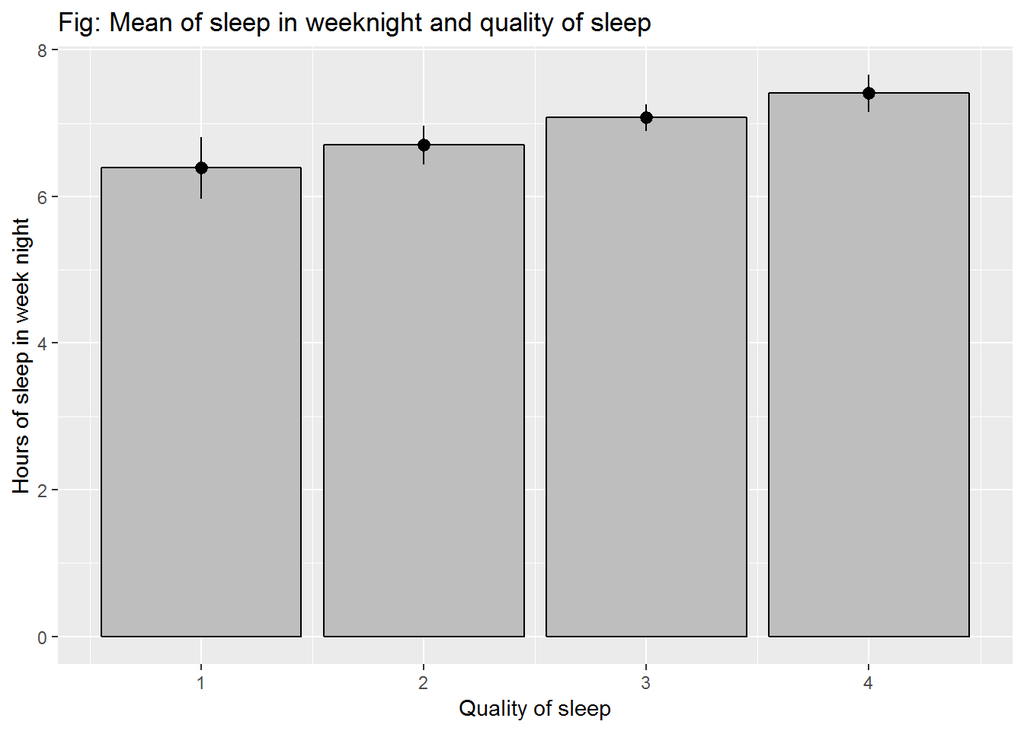

```r
bar_Weeknight <- ggplot(sleep_data, aes(qualsleeprec, hourwnit))
bar_Weeknight + stat_summary(fun.y = mean, geom = "bar", fill = "grey", colour = "Black") + stat_summary(fun.data = mean_cl_normal, geom = "pointrange") + labs(x = "Quality of sleep", y = "Hours of sleep in week night", title="Fig: Mean of sleep in weeknight and quality of sleep")
```

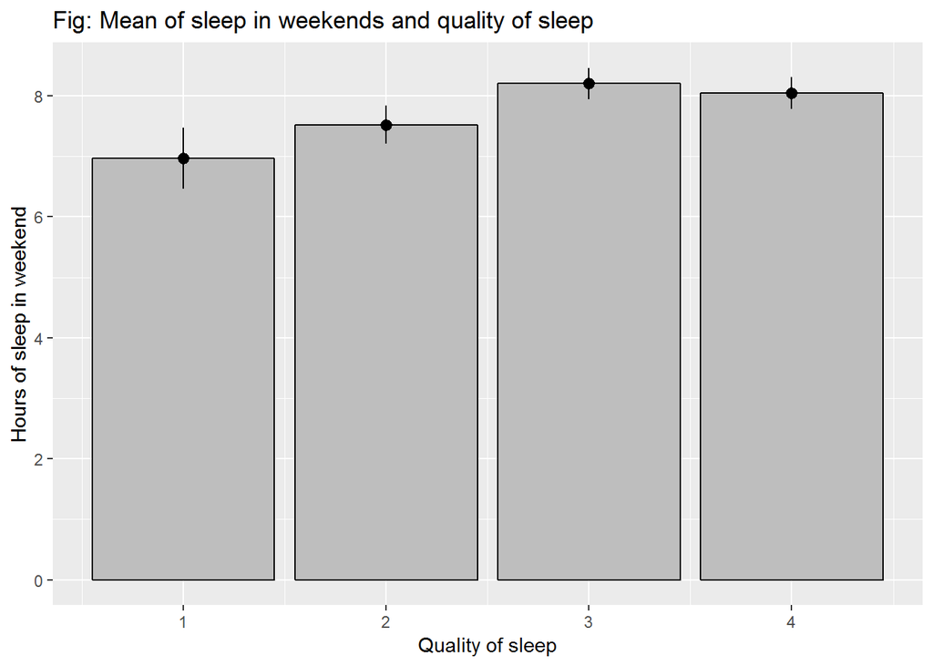

```r
bar_Weekend <- ggplot(sleep, aes(qualsleeprec, hourwend))
bar_Weekend + stat_summary(fun.y = mean, geom = "bar", fill = "grey", colour = "Black") + stat_summary(fun.data = mean_cl_normal, geom = "pointrange") + labs(x = "Quality of sleep", y = "Hours of sleep in weekend", title="Fig: Mean of sleep in weekends and quality of sleep")
```

### 4 “hourwend”(INDEPEDENT VARIABLE)

### 4.1. Variable explanation

```r
pastecs::stat.desc(sleep_data$hourwend, basic=F)
```

```
##       median         mean      SE.mean CI.mean.0.95          var
##   8.00000000   7.80620155   0.08363608   0.16469931   1.80470847
##      std.dev     coef.var
##   1.34339438   0.17209322
```

### 4.2 Descriptive Analysis:

```r
#skewness and kurtosis from semTools with standard error
tpskew<-skew(sleep_data$hourwend)
tpkurt<-kurtosi(sleep_data$hourwend)
stdskew<-tpskew[1]/tpskew[2]
stdkurt<-tpkurt[1]/tpkurt[2]
tpskew
```

```
## [1] -0.1038603
```

```r
tpkurt
```

```
## [1] 2.357775
```

```r
outliers <- sleep %>%
  filter(scale(hourwend) >3.29 | scale(hourwend) < -3.29)
#count them using dplyr summarize
numoutliers<-outliers %>%
  summarize(count=n())
fullcount<-sleep_data %>%
  summarize(count=n())
numoutliers
```

```
##   count
## 1     2
```

```r
fullcount
```

```
##   count
## 1   258
```

### 4.3 Normality Plot

Below graph shows the Normality distribution and density curve of hours of sleep in weekends.

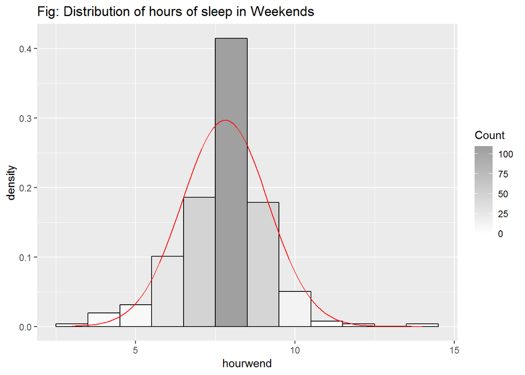

```r
#Create the histogram
hourwend_plot <- ggplot(sleep_data, aes(x= hourwend)) +
  labs(x="hourwend") +
  geom_histogram(binwidth=1, color = "black", aes(y=..density..,fill=..count..)) +
  scale_fill_gradient("Count", low="#FFFFFF", high="#A0A0A0")
hourwend_plot <- hourwend_plot + stat_function(fun=dnorm, color="red",args=list(mean=mean(sleep_data$hourwend, na.rm=TRUE), sd=sd(sleep_data$hourwend, na.rm=TRUE)))
hourwend_plot<-hourwend_plot +ggtitle('Fig: Distribution of hours of sleep in Weekends')
#to display the graph request the contents of the variable be shown
hourwend_plot
```

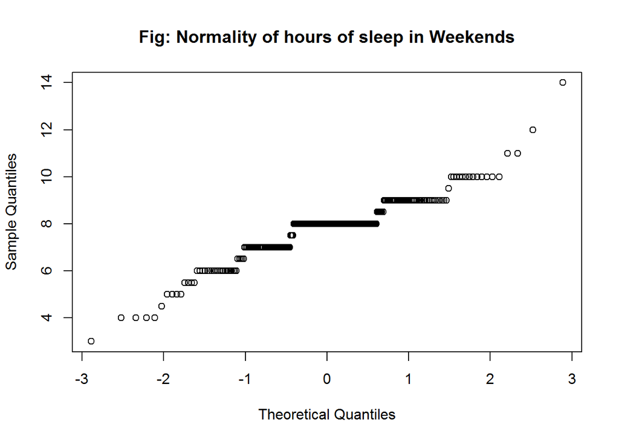

```r
#Create a qqplot
qqnorm(sleep_data$hourwend, main = 'Fig: Normality of hours of sleep in Weekends')
```

### 5.“hourneed”(INDEPEDENT VARIABLE)

### 5.1. Variable explanation

```r
pastecs::stat.desc(sleep_data$hourneed, basic=F)
```

```
##       median         mean      SE.mean CI.mean.0.95          var
##    8.0000000    7.7616279    0.0702356    0.1383106    1.2727242
##      std.dev     coef.var
##    1.1281508    0.1453498
```

### 5.2 Descriptive Analysis:

```r
#skewness and kurtosis from semTools with standard error

tpskew<-skew(sleep_data$hourneed)
tpkurt<-kurtosi(sleep_data$hourneed)
stdskew<-tpskew[1]/tpskew[2]
stdkurt<-tpkurt[1]/tpkurt[2]
tpskew
```

```
## [1] 1.249254
```

```r
tpkurt
```

```
## [1] 10.40844
```

```r
outliers <- sleep %>%
  filter(scale(hourneed) >3.29 | scale(hourneed) < -3.29)
#count them using dplyr summarize
numoutliers<-outliers %>%
  summarize(count=n())
fullcount<-sleep_data %>%
  summarize(count=n())
numoutliers
```

```
##   count
## 1     2
```

```r
fullcount
```

```
##   count
## 1   258
```

### 5.3 Normality Plot:

Below graph shows the Normality distribution and density curve of hours of sleep required for not to feel sleepy next day.

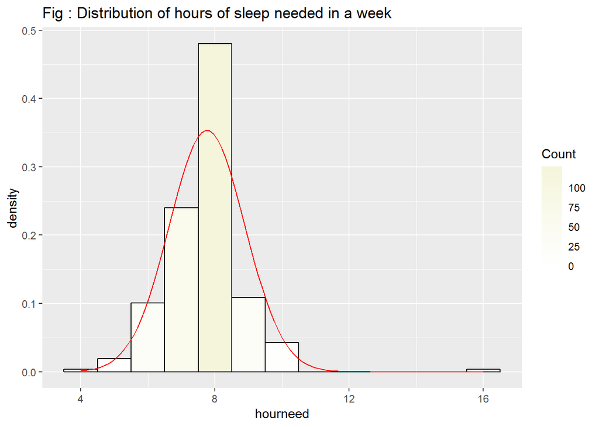

```r
#Create the histogram
hourneed_plot <- ggplot(sleep_data, aes(sleep_data$hourneed)) +
  labs(x="hourneed") +
  geom_histogram(binwidth=1, color = "black", aes(y=..density..,fill=..count..)) +
  scale_fill_gradient("Count", low="#FFFFFF", high="#F5F5DC")
hourneed_plot <- hourneed_plot + stat_function(fun=dnorm, color="red",args=list(mean=mean(sleep_data$hourneed, na.rm=TRUE), sd=sd(sleep_data$hourneed, na.rm=TRUE)))
hourneed <- hourneed_plot +ggtitle('Fig : Distribution of hours of sleep needed in a week')
hourneed
```

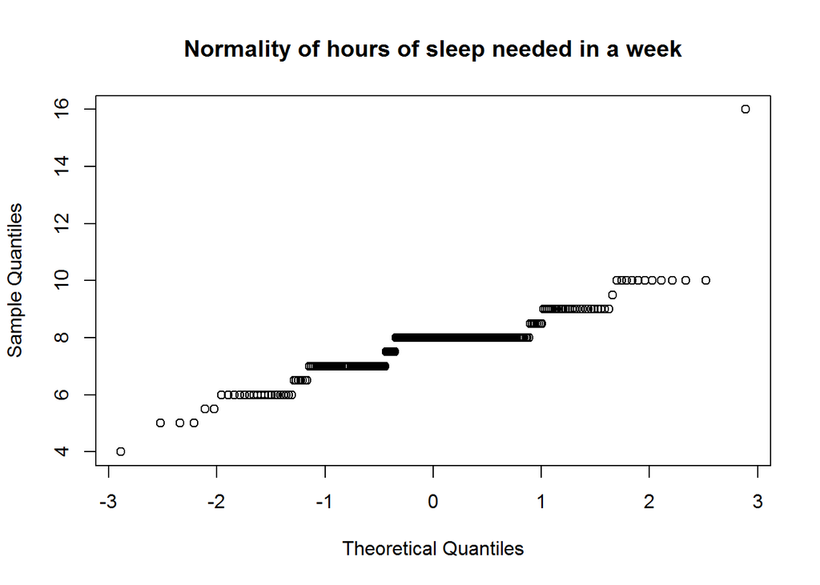

```r
#Create a qqplot
qqnorm(sleep_data$hourneed, main = 'Normality of hours of sleep needed in a week')
```

### Correlation Between the variables for Multiple Linear Regression:

For multiple linear regressions it is necessary to find correlation between the entire variable to see the changes happen in one variable and its effect on model. So before creating Regression model need to find out correlation between all the independent and dependent variables.

### 1. Correlation between Dependent and Independent variables:

### 1.1 Correlation between “hourwnit” and “anxiety”

```r
cor.test(sleep_data$hourwnit, sleep_data$anxiety)
```

```
##
##  Pearson's product-moment correlation
##
## data:  sleep_data$hourwnit and sleep_data$anxiety
## t = -3.1493, df = 256, p-value = 0.001831
## alternative hypothesis: true correlation is not equal to 0
## 95 percent confidence interval:
##  -0.30798418 -0.07271284
## sample estimates:
##       cor
## -0.193123
```

```r
#pearson correlation between hourwnit and anxiety
```

### 1.2 Correlation between “hourwnit” and “qualsleeprec”

```r
Quality_of_sleep <- as.factor(sleep_data$qualsleeprec)
describeBy(sleep_data$hourwnit,group=Quality_of_sleep)
```

```
##
##  Descriptive statistics by group
## group: 1
##    vars  n mean   sd median trimmed  mad min max range  skew kurtosis   se
## X1    1 32 6.39 1.17    6.5    6.52 0.74   3   8     5 -0.89     0.91 0.21
## --------------------------------------------------------
## group: 2
##    vars  n mean   sd median trimmed  mad min max range  skew kurtosis   se
## X1    1 72  6.7 1.13      7    6.74 1.48   4   9     5 -0.26    -0.28 0.13
## --------------------------------------------------------
## group: 3
##    vars  n mean   sd median trimmed  mad min max range  skew kurtosis   se
## X1    1 88 7.07 0.86      7    7.08 1.48   5   9     4 -0.08     -0.6 0.09
## --------------------------------------------------------
## group: 4
##    vars  n mean   sd median trimmed  mad min max range  skew kurtosis   se
## X1    1 66 7.41 1.04   7.25    7.42 1.11   4  10     6 -0.33     0.56 0.13
```

```r
bartlett.test(sleep_data$hourwnit, Quality_of_sleep)#null hypothesis is variances are same
```

```
##
##  Bartlett test of homogeneity of variances
##
## data:  sleep_data$hourwnit and Quality_of_sleep
## Bartlett's K-squared = 7.5391, df = 3, p-value = 0.05656
```

```r
#Can be argued that the variances are homogeneous if the p-value > 0.05
oneway <- userfriendlyscience::oneway(Quality_of_sleep, y = sleep_data$hourwnit, posthoc = 'Tukey')
#printout a summary of the anova
oneway
```

```
## ### Oneway Anova for y=hourwnit and x=Quality_of_sleep (groups: 1, 2, 3, 4)
##
## Omega squared: 95% CI = [.03; .17], point estimate = .09
## Eta Squared: 95% CI = [.04; .15], point estimate = .1
##
##                                     SS  Df   MS    F     p
## Between groups (error + effect)  29.61   3 9.87 9.41 <.001
## Within groups (error only)      266.42 254 1.05
##
##
## ### Post hoc test: Tukey
##
##     diff lwr   upr  p adj
## 2-1 0.31 -0.25 0.87 .483
## 3-1 0.68 0.14  1.23 .008
## 4-1 1.02 0.45  1.59 <.001
## 3-2 0.37 -0.05 0.79 .103
## 4-2 0.71 0.26  1.16 <.001
## 4-3 0.34 -0.1  0.77 .187
```

### 1.3 Correlation between “hourwnit” and “hourneed”

As dependent variable “hourwnit” and Independent variable “hourneed” both are continuous therefore “pearson” correlation is calculated. A Pearson’s r data analysis revealed positive correlation. Where r= 0.44, and p < 0.05 which is lower than conventional 5% therefore correlation coefficient is statically significant.

```r
#for continuous variable


stats::cor.test(sleep_data$hourwnit,sleep_data$hourneed,method = 'pearson')
```

```
##
##  Pearson's product-moment correlation
##
## data:  sleep_data$hourwnit and sleep_data$hourneed
## t = 7.9678, df = 256, p-value = 5.33e-14
## alternative hypothesis: true correlation is not equal to 0
## 95 percent confidence interval:
##  0.3422794 0.5385760
## sample estimates:
##       cor
## 0.4457709
```

### 1.4 Correlation between “hourwnit” and “hourwend”

As dependent variable “hourwnit” and Independent variable “hourwend” both are continuous therefore “pearson” correlation is calculated. A Pearson’s r data analysis revealed good positive correlation. Where r= 0.61, and p < 0.05 which is lower than conventional 5% therefore correlation coefficient is statically significant.

```r
#for continuous variable
stats::cor.test(sleep_data$hourwnit,sleep_data$hourwend,method = 'pearson')
```

```
##
##  Pearson's product-moment correlation
##
## data:  sleep_data$hourwnit and sleep_data$hourwend
## t = 12.253, df = 256, p-value < 2.2e-16
## alternative hypothesis: true correlation is not equal to 0
## 95 percent confidence interval:
##  0.5248643 0.6796727
## sample estimates:
##       cor
## 0.6080161
```

### 2. Correlation between two Independent variables

### 2.1 Correlation between “hourneed” and “hourwend”

As dependent variable “hourwend” and Independent variable “hourneed” both are continuous therefore “pearson” correlation is calculated. A Pearson’s r data analysis revealed good positive correlation. Where r= 0.50, and p < 0.05 which is lower than conventional 5% therefore correlation coefficient is statically significant.

```r
stats::cor.test(sleep_data$hourwend,sleep_data$hourneed,method = 'pearson')
```

```
##
##  Pearson's product-moment correlation
##
## data:  sleep_data$hourwend and sleep_data$hourneed
## t = 9.3381, df = 256, p-value < 2.2e-16
## alternative hypothesis: true correlation is not equal to 0
## 95 percent confidence interval:
##  0.4069933 0.5898772
## sample estimates:
##       cor
## 0.5040643
```

### 2.2 Correlation between “hourwend” and “anxiety”

2. As dependent variable “hourwend” and Independent variable “anxiety” both are continuous therefore “pearson” correlation is calculated. A Pearson’s r data analysis revealed little negative correlation. Where r= -0.14, and p < 0.05 which is lower than conventional 5% therefore correlation coefficient is statically significant.

```r
stats::cor.test(sleep_data$hourwend,sleep_data$anxiety,method = 'pearson')
```

```
##
##  Pearson's product-moment correlation
##
## data:  sleep_data$hourwend and sleep_data$anxiety
## t = -2.1819, df = 256, p-value = 0.03003
## alternative hypothesis: true correlation is not equal to 0
## 95 percent confidence interval:
##  -0.25306717 -0.01321097
## sample estimates:
##       cor
## -0.135118
```

## Results

For Multiple Linear Regression, the hour of sleep “hourwnit” is a response variable and other four variables are the predictor variables. Multiple Linear regressions is about many to one relationship between respondent and predictor variable. The equation for multiple linear regressions is shown below:

```
y = b0 + b1x1 + b2x2 + .. + bnxn + ei
```

Here, Y is the response variable which is “hourwnit”, b0 is the intercept which will be calculated by creating 3 models. B1, B2 , B3 and B4 are the regression coefficient and ei is the error coefficient. Multiple regression analysis is done by creating three models and adding predictor variable one by one.

### Model1(Baselie Model)

My baseline model includes respondent variable as “hourwnit” and predictor variable as “hourneed” and “anxiety”. If we compare this with the equation of multiple linear regressions than equation will look like

```
Y ("hourwnit") = B0 + B1("hourneed")+B2("anxiety")
```

The correlation between these three variables is already discussed in previous section so now after creating a Baseline Regression model we get coefficients. The prediction of sleep hour in weeknight will be done with the help of data which shows hour needed to sleep for not to feel sleepy next day and anxiety score. After creating the model we will get coefficients and after fitting the coefficients in the equation, it will look like:

```
Y ("hourwnit") = 4.00075   +  0.43912 ("hourneed") -0.07003  ("anxiety")
```

To get some more statical result we will analyze summary of regression model 1. The regression model created by Lm function where n is the number of explanatory variable used for the Multiple Linear Regression model.

```
Lm(response ~ explanatory_1 + explanatory_2 +..+ explanatory_n)
```

Here most important result is P value which is the probability value. This will indicate that statical significance of the variable is contributing to the model. In this model both the variables “hourneed” and “anxiety” are contributing statically significantly to the model. A significant equation was calculated to predict “hourwnit” based on hourneed" and “anxiety”. A significant regression equation was found (F(255) = 42.34, p < .001) with R<sup>2</sup> of 0.2434. Participant’s predicted “hourneed” is equal to 4.00 +0.44 (“hourneed”) -0.07 (“anxiety”) where anxiety count in number from 0-17 and “hourneed” is coded or measured in hour.

```r
regression1 <- lm(hourwnit~hourneed + anxiety, sleep_data)
regression1 #view basic regression model
```

```
##
## Call:
## lm(formula = hourwnit ~ hourneed + anxiety, data = sleep_data)
##
## Coefficients:
## (Intercept)     hourneed      anxiety
##     4.00075      0.43912     -0.07003
```

```r
summary(regression1) #summary of regression
```

```
##
## Call:
## lm(formula = hourwnit ~ hourneed + anxiety, data = sleep_data)
##
## Residuals:
##     Min      1Q  Median      3Q     Max
## -3.9535 -0.5844 -0.0284  0.6264  2.7664
##
## Coefficients:
##             Estimate Std. Error t value Pr(>|t|)
## (Intercept)  4.00075    0.41219   9.706  < 2e-16 ***
## hourneed     0.43912    0.05174   8.486 1.77e-15 ***
## anxiety     -0.07003    0.01689  -4.145 4.62e-05 ***
## ---
## Signif. codes:  0 '***' 0.001 '**' 0.01 '*' 0.05 '.' 0.1 ' ' 1
##
## Residual standard error: 0.9335 on 255 degrees of freedom
## Multiple R-squared:  0.2493, Adjusted R-squared:  0.2434
## F-statistic: 42.34 on 2 and 255 DF,  p-value: < 2.2e-16
```

There are few more analysis for Baseline Model which are explained in below points:

1. Cook’s distance consider the cases on the model, as per (Field (2013)) if cook’s distance is >1 then that outlier is point of concern. In this regression model we are getting one point >1 at 157 which need to be analyzed.The other two outliers are at 75 and 246 which is not expected to have as significant impact.
2. Leverage values lies at 0 indicate that case has no influence and 1 shows that 1 has complete prediction over the influence. Here the outliers far from the leverage line might cause point of concern.

3.VIF values(hourneed, VIF= 1.00; anxiety, VIF= 1.00) and were within acceptable levels (VIF<2.5)(Field (2013)). This has been measured to understand collinearity.

4.The density plot shows the distribution of standardized residuals and shows the distributed error.

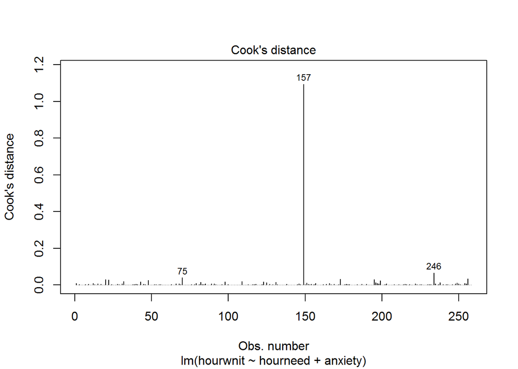

```r
#Plot Cooks distance
cook <- 4/((nrow(sleep_data)- length(regression1$coefficients)-1))
plot(regression1, which = 4, cook.levels = cook)
```

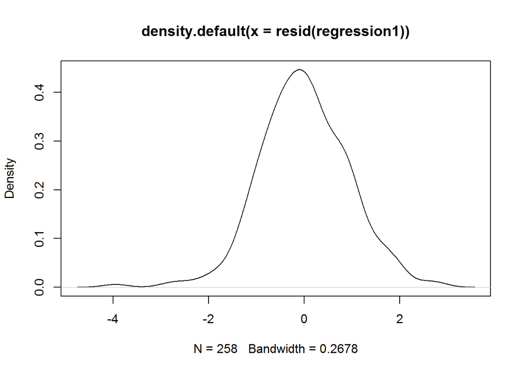

```r
#Create histogram
#A density plot of the residuals
plot(density(resid(regression1)))
```

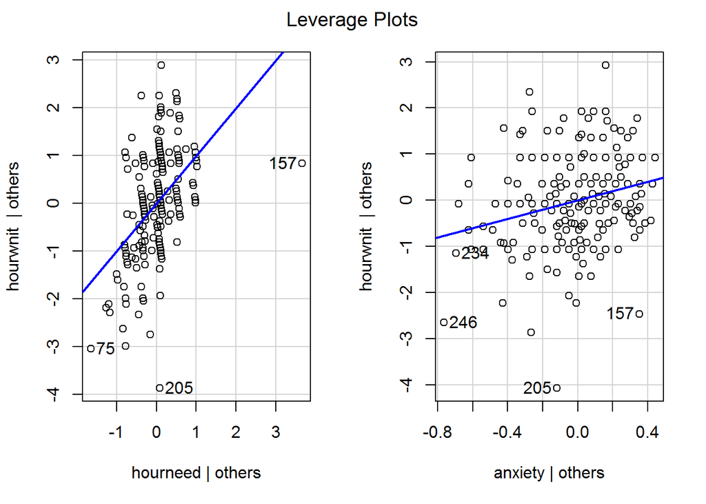

```r
#Create a QQ plotqqPlot(model, main="QQ Plot") #qq plot for studentized resid
leveragePlots(regression1) # leverage plots
```

```r
#Collinearity
vifmodel<-vif(regression1)
vifmodel
```

```
## hourneed  anxiety
## 1.004938 1.004938
```

```r
#Calculate tolerance
1/vifmodel
```

```
##  hourneed   anxiety
## 0.9950864 0.9950864
```

### Illustration of Baseline Model by Example

[output not shown]

## Model 1

In this model will use result of Baseline model and add one more Independent variable “qualsleeprec”. This model includes respondent variable as “hourwnit” and predictor variable as “hourneed”, “anxiety” and “qualsleeprec”. If we compare this with the equation of multiple linear regressions than equation will look like

```
  Y ("hourwnit") = B0 + B1("hourneed")+B2("anxiety") +B3 ("qualsleeprec")
```

The correlation between these three variables is already discussed in previous section so now after creating a Regression model we get coefficients. The prediction of sleep hour in weeknight will be done with the help of data which shows hour needed to sleep for not to feel sleepy next day and anxiety score. After creating the model we will get coefficients and after fitting the coefficients in the equation, it will look like:

```
  Y ("hourwnit") =   2.83396  +  0.44883 ("hourneed") -0.03931 ("anxiety") + 0.32956("qualsleeprec")
```

In this model both the variables “hourneed” and “qualsleeprec” are contributing statically significantly to the model but because of addition of new variable the significance of “anxiety” is reduced. However, there is one asterisk present at the result there for its still little significant to be considered. A significant equation was calculated to predict “hourwnit” based on hourneed“,”qualsleeprec" ,“anxiety”. A significant regression equation was found (F(254) = 41.68, p < .001) with R<sup>2</sup> of 0.322. Participant’s predicted “hourneed” is equal to 2.83+0.45(“hourneed”) -0.03 (“anxiety”) + 0.33 (“qualsleeprec”).

```r
regression2 <- lm(hourwnit~hourneed + anxiety + qualsleeprec , sleep_data)
regression2
```

```
##
## Call:
## lm(formula = hourwnit ~ hourneed + anxiety + qualsleeprec, data = sleep_data)
##
## Coefficients:
##  (Intercept)      hourneed       anxiety  qualsleeprec
##      2.83396       0.44883      -0.03931       0.32956
```

```r
summary(regression2)
```

```
##
## Call:
## lm(formula = hourwnit ~ hourneed + anxiety + qualsleeprec, data = sleep_data)
##
## Residuals:
##     Min      1Q  Median      3Q     Max
## -3.4396 -0.5958 -0.0259  0.5617  2.4144
##
## Coefficients:
##              Estimate Std. Error t value Pr(>|t|)
## (Intercept)   2.83396    0.44364   6.388 7.97e-10 ***
## hourneed      0.44883    0.04902   9.157  < 2e-16 ***
## anxiety      -0.03931    0.01693  -2.322    0.021 *
## qualsleeprec  0.32956    0.05962   5.527 8.06e-08 ***
## ---
## Signif. codes:  0 '***' 0.001 '**' 0.01 '*' 0.05 '.' 0.1 ' ' 1
##
## Residual standard error: 0.8837 on 254 degrees of freedom
## Multiple R-squared:  0.3299, Adjusted R-squared:  0.322
## F-statistic: 41.68 on 3 and 254 DF,  p-value: < 2.2e-16
```

There are few more analysis for Model 1 which are explained in below points:

1. Cook’s distance consider the cases on the model, as per (Field (2013)) if cook’s distance is >1 then that outlier is point of concern. In this regression model we are getting one point >1 at 157 which need to be analyzed. The other two outliers are at 75 and 205 which is not expected to have as significant impact.

2.Leverage values lies at 0 indicate that case has no influence and 1 shows that 1 has complete prediction over the influence. Here the outliers far from the leverage line might cause point of concern.

3.VIF values(hourneed, VIF= 1.006; anxiety, VIF= 1.126; qualsleeprec, VIF= 1.124 ) and were within acceptable levels (VIF<2.5 ).

4.The density plot shows the distribution of standardized residuals and shows the distributed error.

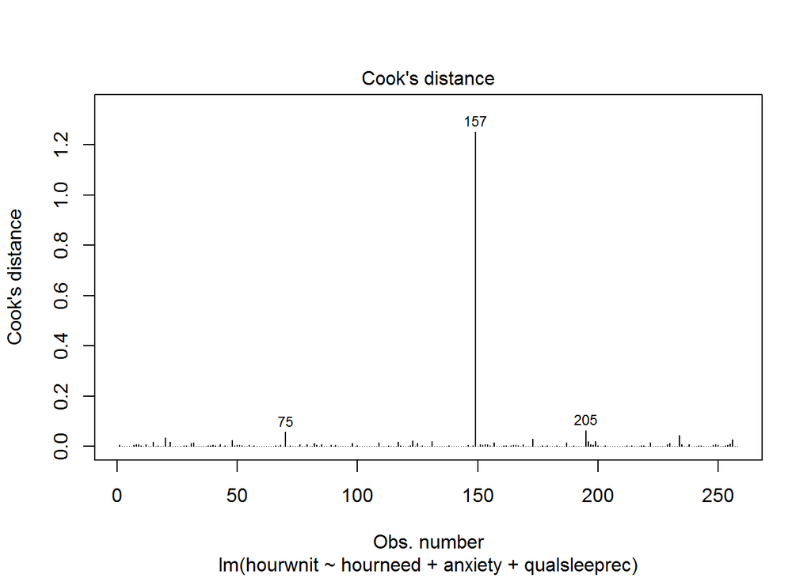

```r
#Plot Cooks distance
cook1 <- 4/((nrow(sleep_data)- length(regression2$coefficients)-1))
plot(regression2, which = 4, cook.levels = cook1)
```

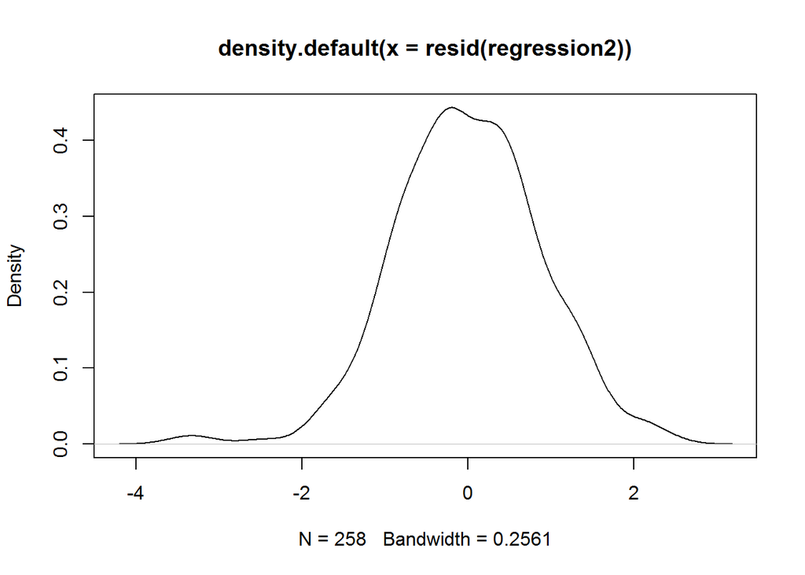

```r
#Create histogram
#A density plot of the residuals
plot(density(resid(regression2)))
```

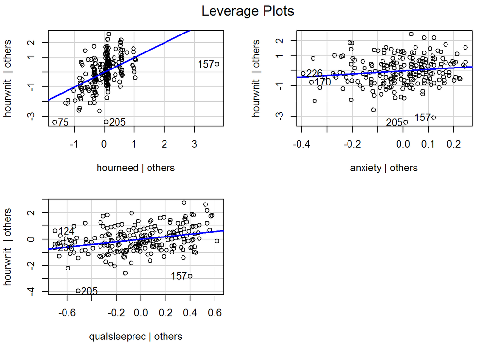

```r
#Create a QQ plotqqPlot(model, main="QQ Plot") #qq plot for studentized resid
leveragePlots(regression2) # leverage plots
```

```r
#Collinearity
vifmodel1<-vif(regression2)
vifmodel1
```

```
##     hourneed      anxiety qualsleeprec
##     1.006231     1.126275     1.124387
```

```r
#Calculate tolerance
1/vifmodel1
```

```
##     hourneed      anxiety qualsleeprec
##    0.9938073    0.8878827    0.8893735
```

### Illustration of Model1 by Example

1. For Quality of sleep = 1

   ```
   Y ("hourwnit") = 2.83396 + 0.44883 (7.0) - 0.03931(6) + 0.32956(1)
                      = 2.83396 +3.14181-0.23586+0.32956
                      = 6.06947
   ```

2. For Quality of sleep = 2

   ```
   Y ("hourwnit") = 2.83396 + 0.44883 (7.0) - 0.03931(6) + 0.32956(2)
                    = 2.83396 +3.14181-0.23586+0.65912
                    = 6.39907
   ```

3.For Quality of sleep = 3

```
    Y ("hourwnit") = 2.83396 + 0.44883 (7.0) - 0.03931(6) + 0.32956(3)
                       = 2.83396 +3.14181-0.23586+0.98868
                       = 6.72863
```

4.For Quality of sleep = 4

[output not shown]

## Model 2

```
  Y ("hourwnit") = B0 + B1("hourneed")+B3 ("qualsleeprec")+B4("hourwend")
```

The correlation between these three variables is already discussed in previous section so now after creating a Regression model we get coefficients. The prediction of sleep hour in weeknight will be done with the help of data which shows hour needed to sleep for not to feel sleepy next day and average hour of sleep on weekends. After creating the model we will get coefficients and after fitting the coefficients in the equation, it will look like:

```
  Y ("hourwnit") =   1.8877 + 0.2308 ("hourneed") +0.2307 ("qualsleeprec") +0.3411 ("hourwend")
```

In this model both the variables “hourneed”,“qualsleeprec” and “hourwend” are contributing statically significantly to the model. A significant equation was calculated to predict “hourwnit” based on hourneed“,”qualsleeprec" ," hourwend“. A significant regression equation was found (F(254) = 65.01, p < .001) with R<sup>2</sup> of 0.4276. Participant’s predicted”hourneed" is equal to 1.8877 +0.23(“hourneed”) +0.23 (“qualsleeprec”) + 0.34(“hourwend”).

```r
Regression3 <- lm(hourwnit~ hourneed+qualsleeprec+hourwend, sleep_data)
Regression3
```

```
##
## Call:
## lm(formula = hourwnit ~ hourneed + qualsleeprec + hourwend, data = sleep_data)
##
## Coefficients:
##  (Intercept)      hourneed  qualsleeprec      hourwend
##       1.8877        0.2308        0.2307        0.3411
```

```r
summary(Regression3)
```

```
##
## Call:
## lm(formula = hourwnit ~ hourneed + qualsleeprec + hourwend, data = sleep_data)
##
## Residuals:
##      Min       1Q   Median       3Q      Max
## -2.26498 -0.49573  0.01329  0.61459  2.07608
##
## Coefficients:
##              Estimate Std. Error t value Pr(>|t|)
## (Intercept)   1.88765    0.39654   4.760 3.25e-06 ***
## hourneed      0.23076    0.05352   4.311 2.32e-05 ***
## qualsleeprec  0.23072    0.05539   4.165 4.27e-05 ***
## hourwend      0.34110    0.04673   7.299 3.71e-12 ***
## ---
## Signif. codes:  0 '***' 0.001 '**' 0.01 '*' 0.05 '.' 0.1 ' ' 1
##
## Residual standard error: 0.812 on 254 degrees of freedom
## Multiple R-squared:  0.4343, Adjusted R-squared:  0.4276
## F-statistic: 65.01 on 3 and 254 DF,  p-value: < 2.2e-16
```

There are few more analysis for Model 2 which are explained in below points:

1.In this regression model we are getting all the outliers < 1. Therefore these three outliers 131, 157 and 205 does not expected to have as significant impact on the model.

2.Leverage values lies at 0 indicate that case has no influence and 1 shows that 1 has complete prediction over the influence. Here the outliers far from the leverage line might cause point of concern.

4.The density plot shows the distribution of standardized residuals and shows the distributed error.

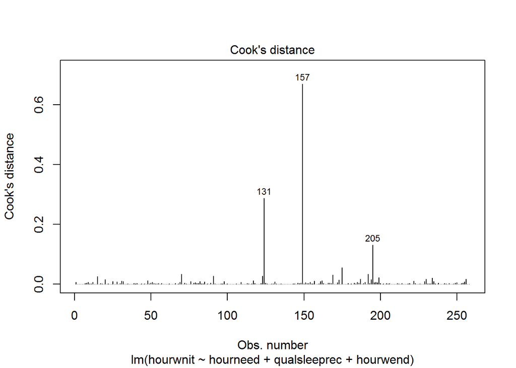

```r
cook2 <- 4/((nrow(sleep_data)- length(Regression3$coefficients)-1))
plot(Regression3, which = 4, cook.levels = cook2)
```

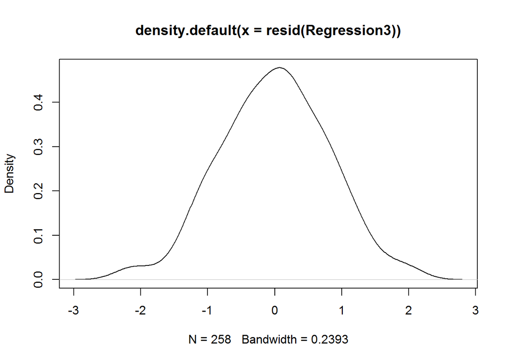

```r
#Create histogram
#A density plot of the residuals
plot(density(resid(Regression3)))
```

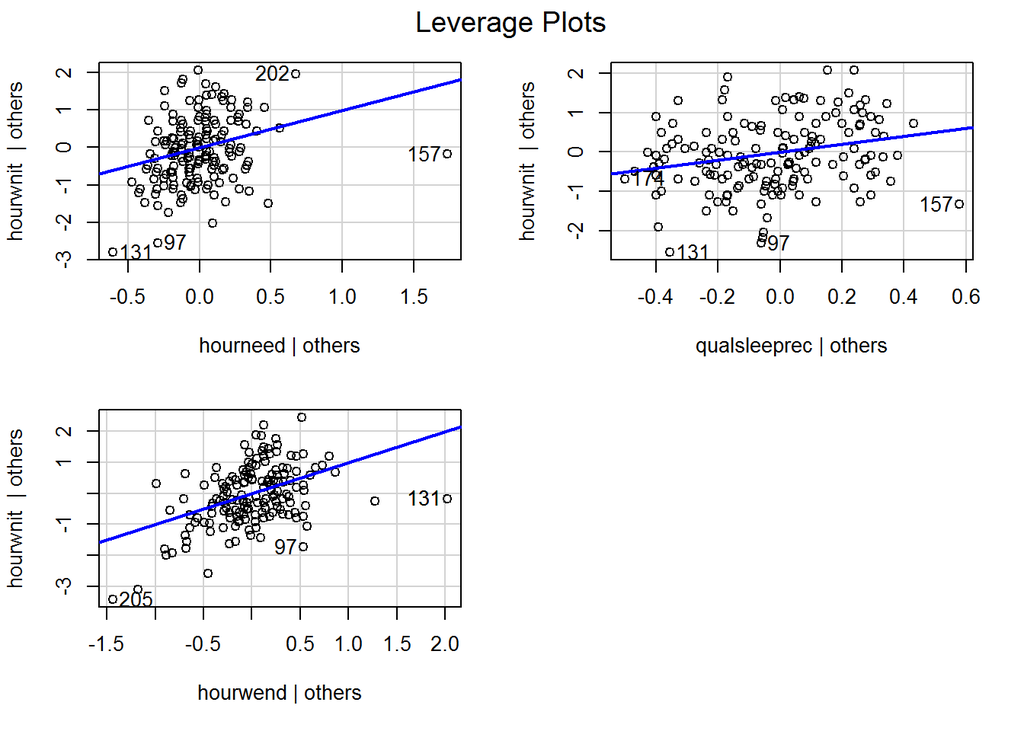

```r
#Create a QQ plotqqPlot(model, main="QQ Plot") #qq plot for studentized resid
leveragePlots(Regression3) # leverage plots
```

```r
#Collinearity
vifmodel2<-vif(Regression3)
vifmodel2
```

```
##     hourneed qualsleeprec     hourwend
##     1.421289     1.149657     1.536264
```

```r
#Calculate tolerance
1/vifmodel2
```

```
##     hourneed qualsleeprec     hourwend
##    0.7035868    0.8698250    0.6509299
```

### Illustration of Model2 by Example

This is the most accurate model with confidance of 42% , lets see prediction by putting value in the model.

```
 Y ("hourwnit") = 1.8877 + 0.2308 (7.81) +0.2307(3)+ 0.3411(8)
                  = 1.8877 + 1.8025 + 0.6921 + 2.7288
                = 7.111
```

here the prediction of sleep hour in weeknight came upto 7.111 hour of sleep on an average in weekdays.

### Conclusion

Significance level of the entire model is p < .001. Except “anxiety” all the variables used for the model are significant and had p < 0.001. The value of R square is increasing by adding variable in each model. The baseline model has R Square = 0.2434 that means variance of sleep hour prediction is 24.34%. After adding one more variable in Model 1 the value of R Square = 0.322 which is increased therefore variance on sleep hour prediction changed to 32.22%. The main concern about these two models is outliers in Cook’s distance which have one outlier having cook’s distance > 1which was point of concern. The last model i.e Model 2 which has independent variable as “hourwed”, “hourneed” and “qualsleeprec” is the best fit for the linear regression. First of all variance for this model is 43.43% and cook’s distance of outliers is < 1 which does not make significant impact on Regression model. Hence, the aim of analysis is to predict hour of sleep in weeknight with the help of three different independent variable. With the variance significance of 43.43 % we will able to predict the sleep hour with confidence level of 43%.

### Reference :

Merilahti, J., Saarinen, A., Parkka, J., Antila, K., Mattila, E. and Korhonen, I. (2007). Long-Term Subjective and Objective Sleep Analysis of Total Sleep Time and Sleep Quality in Real Life Settings - IEEE Conference Publication. [online] Ieeexplore.ieee.org. Available at: https://ieeexplore.ieee.org/document/4353514

Goldstein-Piekarski, A., Greer, S., Saletin, J., Harvey, A., Williams, L. and Walker, M. (2018). Sex, Sleep Deprivation, and the Anxious Brain - MITP Journals & Magazine. [online] Ieeexplore.ieee.org. Available at: https://ieeexplore.ieee.org/document/8305732

Williams, J. and Cook, D. 2018. Using Time Series Techniques to Forecast and Analyze Wake and Sleep Behavior. [online] Eecs.wsu.edu. Available at: https://www.eecs.wsu.edu/~cook/pubs/kdd16.pdf [Accessed 30 Nov. 2018].

Chervin, R., Dillon, J., Bassetti, C., Ganoczy, D. and Pituch, K. (1997). Symptoms of Sleep Disorders, Inattention, and Hyperactivity in Children. [online] Available at: https://academic.oup.com/sleep/article/20/12/1185/2750014

Field, “Discovering Statistics using IBM SPSS Statistics” (2013)